# Introduction to Text Analysis in R (Activity 2) - With solutions

Christian Staal Bruun Overgaard

April 25, 2023

In this tutorial, you’ll get the chance to use the skills you learned about in *Activity 1*. Please feel free to go through the exercises below with a dataset of your own. This notebook has the solutions to *Activity 2*, assuming you’re using the dataset provided by me: *10K_Facebook_posts_for_tutorial_USnewsoutlets.csv*. Before looking at the solutions, I recommend trying the *no solutions* version to see how much of Activity 2 you can do on your own by using what you learned (and the code you got) in Activity 1.

## Load packages

```r
library(readr) #for reading csv's
library(readxl) #for reading Excel sheets
library(tidytext) #main package for text analysis
library(tidyverse) #collection of useful packages
```

```r
library(ggthemes) #for customizing plots
library(wordcloud)
```

## Import Data

### Load

First, load either (A) Your own data, or (B) the file, “10K_Facebook_posts_for_tutorial_USnewsoutlets.csv” into R:

```r
dat <- read_csv("10K_Facebook_posts_for_tutorial_USnewsoutlets.csv")
```

### Inspect

Do a quick inspection of the data. TIP: You can use the head() function.

```r
glimpse(dat)
```

```
## Rows: 10,000
## Columns: 43
## $ `Page Name`                                                                                                        <chr> …
## $ `User Name`                                                                                                        <chr> …
## $ `Facebook Id`                                                                                                      <dbl> …
## $ `Page Category`                                                                                                    <chr> …
## $ `Page Admin Top Country`                                                                                           <chr> …
## $ `Page Description`                                                                                                 <chr> …
## $ `Page Created`                                                                                                     <chr> …
## $ `Likes at Posting`                                                                                                 <chr> …
## $ `Followers at Posting`                                                                                             <chr> …
## $ `Post Created`                                                                                                     <chr> …
## $ `Post Created Date`                                                                                                <chr> …
## $ `Post Created Time`                                                                                                <time> …
## $ Type                                                                                                               <chr> …
```

[output cut: 30 more lines]

### Select the relevant columns

Some of the variables consistent of two or more words seperated by blank spaces. That’s quite inconvenient; in R, life is easier when there are no blank spaces in our variable names. Fortunately, the `janitor` package makes it easy to standardize the column names in a given dataset:

```r
#install.packages("janitor")
df <- janitor::clean_names(dat) #Here, we're putting the package name in front the function name, instead of loading the package before using it.

colnames(df) |> head(10) #look at the names of the first 10 columns in df
```

```
##  [1] "page_name"              "user_name"              "facebook_id"
##  [4] "page_category"          "page_admin_top_country" "page_description"
##  [7] "page_created"           "likes_at_posting"       "followers_at_posting"
## [10] "post_created"
```

```r
df <- df |> select(id, message, user_name)
```

## Subsetting data

### Use words to subset

Try to subset to include only messages that mention the word “President”

```r
df_pres <- df[grepl("President"
                     , df$message, ignore.case=TRUE),]
```

Now, try to subset to messages that include either the word “President” OR the word “Biden”:

```r
df_either <- df[grepl("President|Biden"
                     , df$message, ignore.case=TRUE),]
```

### Bonus: Looking at only specific Facebook pages

We didn’t talk about this in the first tutorial but if you wanted to only view content from a specific Facebook page, this is how you could do it:

```r
df_thehill <- df %>%
  filter(user_name == "TheHill")
```

- This kinds of filtering can be useful. The plots we’re doing below could, for example, be done for different news outlets.

In this tutorial, we’ll analyze the full dataset (so we will use the dataframe called “df”).

## Working with the TidyText package

### Transform data to relevant structures

#### Tokenizing

First, use the function, `unnest_tokens` to tokenize the data. Remember, the function takes two arguments: level you want to tokenize at (use “word”) and the name of the column with the text (in our case “message”).

```r
df_tok <- df |> unnest_tokens(word, message)
```

Now, do a count to identify the most common words. (HINT: It’s totally fine to look at the code from Activity 1 or from any other source.)

```r
df_tok %>%
  dplyr::count(word, sort = TRUE)
```

```
## # A tibble: 23,181 × 2
##    word      n
##    <chr> <int>
##  1 the   11591
##  2 to     6103
##  3 a      5755
##  4 of     5127
##  5 and    4308
##  6 in     4282
##  7 for    2269
##  8 is     2216
##  9 on     2116
## 10 that   1956
## # ℹ 23,171 more rows
```

#### Removing “stopwords”

It’s hard to gauge the meaning of the content, with all these stop words, right? Let’s try to remove them! (HINT: you can use the anti_join function.)

```r
df_no_stopwords <- df_tok %>%
  anti_join(stop_words)
### and then we can do the count again:
df_no_stopwords %>%
  dplyr::count(word, sort = TRUE)
```

```
## # A tibble: 22,533 × 2
##    word          n
##    <chr>     <int>
##  1 https      1110
##  2 trump      1037
##  3 president   970
##  4 people      624
##  5 http        588
##  6 news        499
##  7 house       388
##  8 u.s         382
##  9 donald      351
## 10 time        314
## # ℹ 22,523 more rows
```

Remove any additional words that you think would be helpful to remove:

```r
additional_stopwords <- data.frame(word = c("http", "https"), lexicon = "custom")

### combine the additional stopwords with tidytext's original list of stopwords:
all_my_stopwords <- rbind(stop_words, additional_stopwords)
tail(all_my_stopwords)
```

```
## # A tibble: 6 × 2
##   word     lexicon
##   <chr>    <chr>
## 1 younger  onix
## 2 youngest onix
## 3 your     onix
## 4 yours    onix
## 5 http     custom
## 6 https    custom
```

Now, do a final count of the top words:

```r
df_no_stopwords <- df_tok %>%
  anti_join(all_my_stopwords)
df_no_stopwords %>%
  dplyr::count(word, sort = TRUE)
```

```
## # A tibble: 22,531 × 2
##    word          n
##    <chr>     <int>
##  1 trump      1037
##  2 president   970
##  3 people      624
##  4 news        499
##  5 house       388
##  6 u.s         382
##  7 donald      351
##  8 time        314
##  9 police      279
## 10 white       276
## # ℹ 22,521 more rows
```

### Visualizing common words

#### Bar plot

Next, make the initial preperation for the ggplot (HINT: use the functions, count, filter, mutate—encouraged to look at the code from Activity 1).

How many times do you think a word needs to appear to be worth including in the bar plot? (HINT: use the table above as a reference point when making that decision.)

```r
(df_filtered <- df_no_stopwords %>%
  dplyr::count(word, sort = TRUE) %>% #this is the same step as before
  filter(n > 280) %>% #decide how frequently a word must appear to be included
  mutate(word = reorder(word, n))    )
```

```
## # A tibble: 8 × 2
##   word          n
##   <fct>     <int>
## 1 trump      1037
## 2 president   970
## 3 people      624
## 4 news        499
## 5 house       388
## 6 u.s         382
## 7 donald      351
## 8 time        314
```

Then, build the basic ggplot:

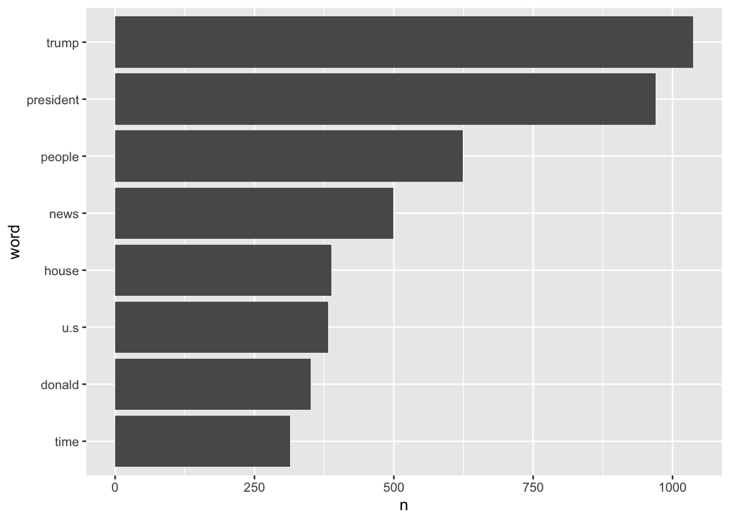

```r
(myplot <- df_filtered %>%
  ggplot(aes(word, n)) + #use ggplot
  geom_col() + #
  coord_flip()    )
```

Try making the plot look nicer by adding some labels and a theme:

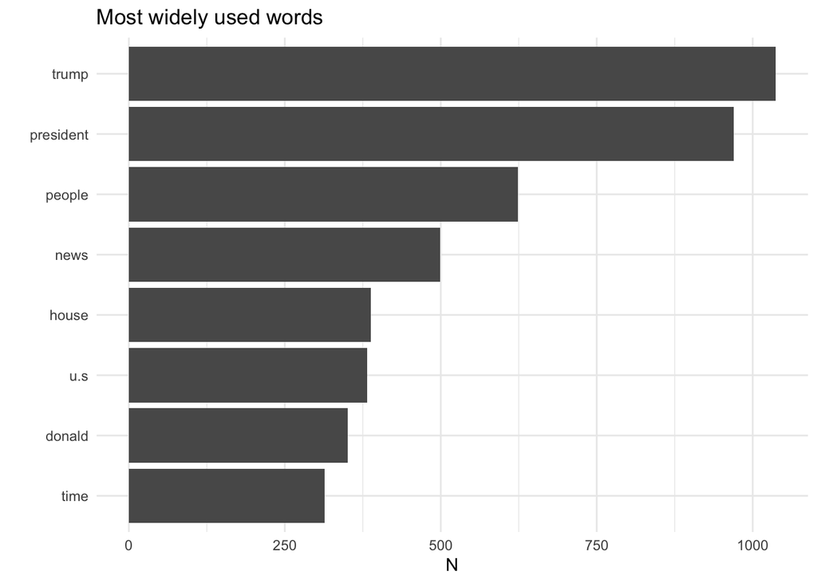

```r
myplot +
  labs(
        title="Most widely used words",
        x ="",
        y = "N") + #remember: X and Y has been flipped
  theme_minimal()
```

##### Wordcloud

As the final step, try making a word cloud:

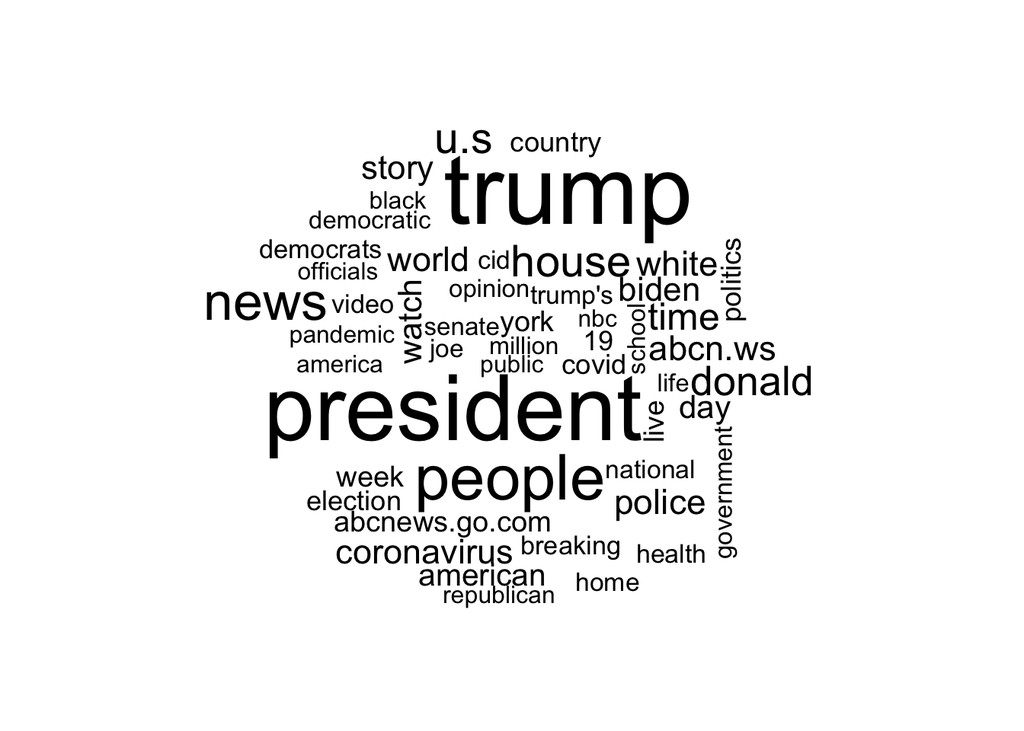

```r
set.seed(3) #play with different seeds
df_no_stopwords %>%
  dplyr::count(word, sort = TRUE) %>% #same count as before
  with(wordcloud::wordcloud(word, n, max.words = 50
                            #, colors = c("blue", "darkblue", "black")
                            ))
```